# Donor Profile: Mastercard Foundation

## Focus Portfolio

The Mastercard Foundation portfolio reveals a striking funding disparity: while total donor funding averages $19.6M, a top outlier reaches nearly $296M. This concentration signals both risk and opportunity for diversified resource mobilization. Six UNHCR regions engage 16 unique initiatives, underscoring a broad geographic scope that aligns with donor priorities on emergency response and resilience. However, variability in funding levels suggests strategic gaps where scaling successful models can multiply impact. Investing to expand mid-range funded projects, currently averaging below $1.4M, can leverage proven approaches into emerging regional priorities. Prioritizing partnerships that address these disparities permits risk mitigation and optimizes return on investment by aligning resources with high-impact, scalable interventions. We recommend immediate executive focus on reallocating resources towards underfunded regions and amplifying collaboration with Mastercard Foundation-funded initiatives demonstrating replicable success. This focused investment pathway unlocks amplified humanitarian outcomes and strengthens accountability frameworks, making this an urgent strategic priority for major donors aiming to maximize impact.

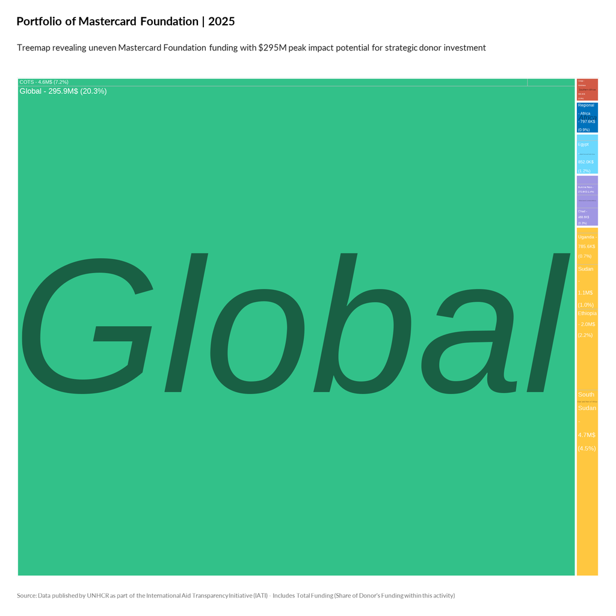

TRUE

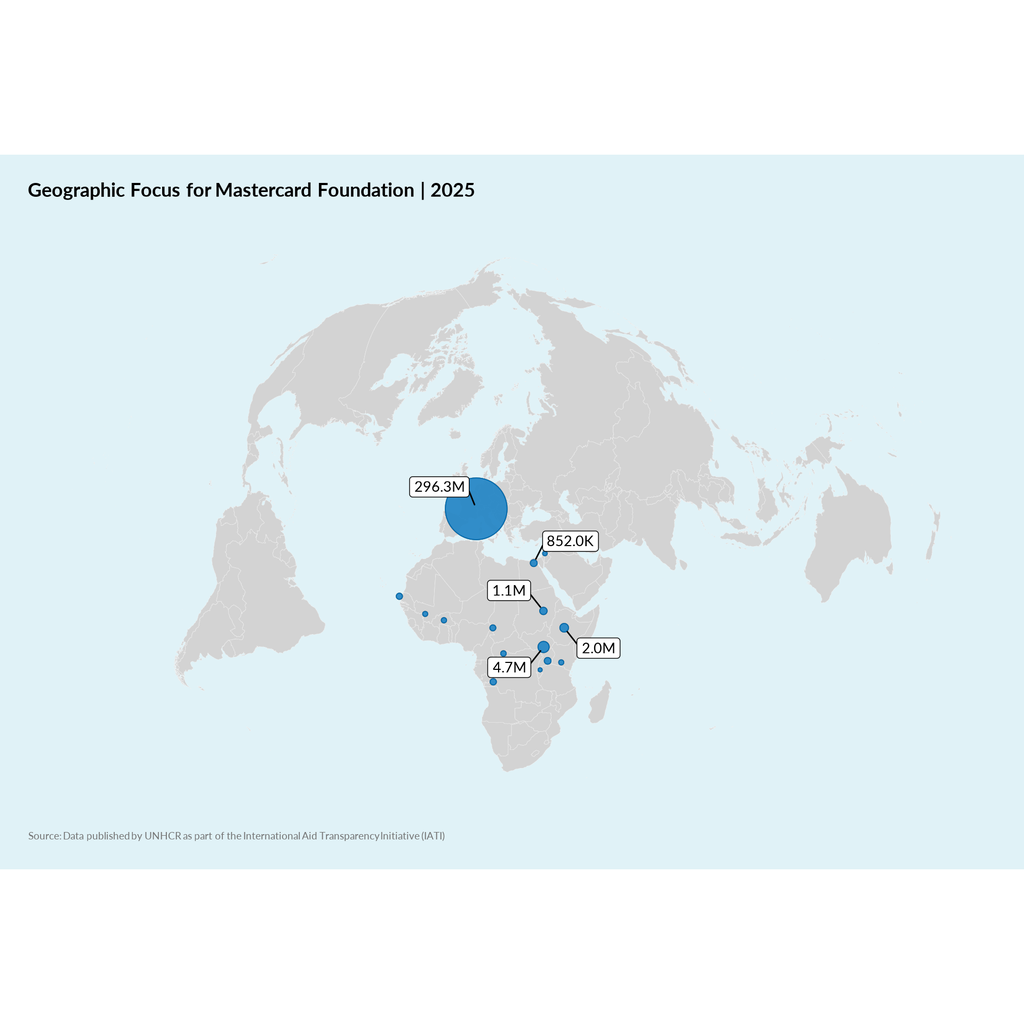

TRUE